# My visual data story

A journey into my Auckland bus commute!

Zhiyi Wan

2026-05-05

## My Data Story: What Affects My Bus Commute?

Over several weeks, I logged data about my bus trips between home and university in Auckland. I recorded weather conditions, travel duration, vehicle fullness, time of day, and who was on the bus. This visual data story explores three key questions about my commute.

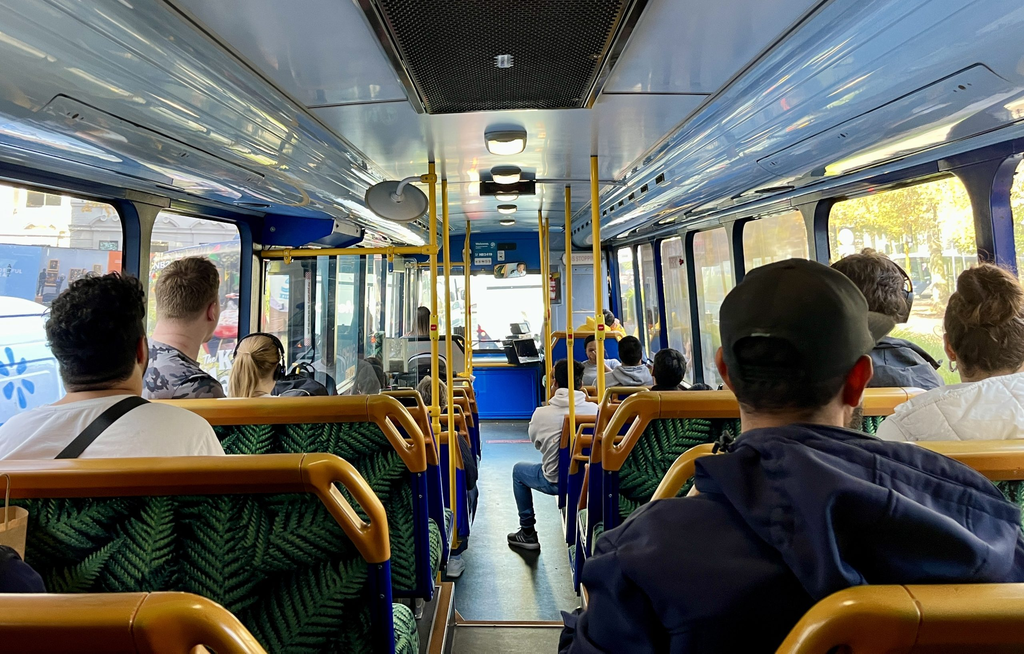

Auckland AT bus

## Does Rain Make My Bus Trip Longer?

Data collection was going well, but I didn’t start recording weather until later in the project. I realised that sunny days felt faster, but I wanted to know for sure, does rain actually make my trip longer? So I added a weather question to my Google Form and kept logging my commutes.

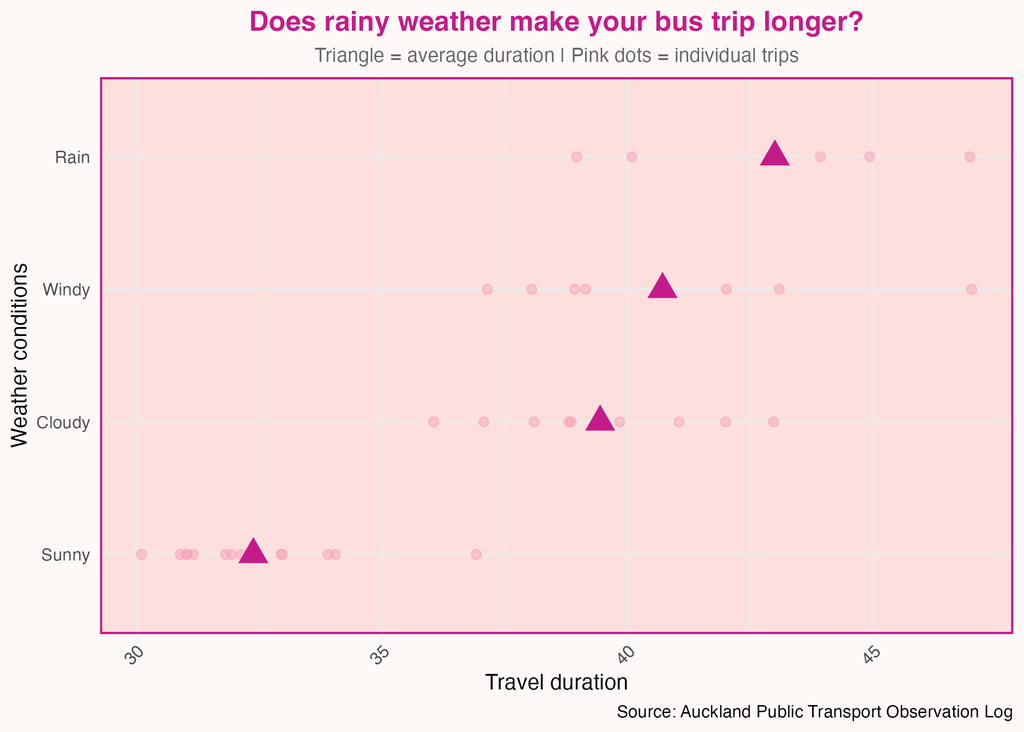

Rainy days clearly take longer than sunny days, no surprise there. But windy days also show longer trips, which I didn’t expect. Windy conditions might mean slower driving or more cautious bus drivers. The pink dots also tell me something interesting: rainy and windy day trips vary a lot. Some rainy and windy trips are only a little slower, but others are much slower. Sunny day trips are more predictable.

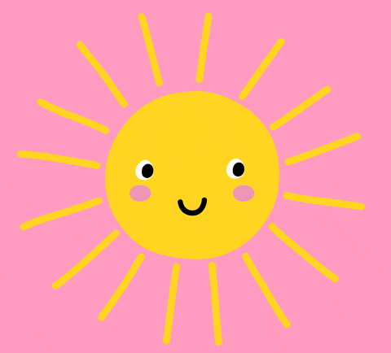

A cute sunshine

## When Is the Bus Most Crowded?

I started paying attention to fullness after a few uncomfortable trips standing in the aisle, backpack squishing people, trying not to fall over. So I logged how full the bus felt each time, Empty, Light, Moderate, Busy, or Very Busy. Then I looked at the hour of the day to see if there was a pattern.

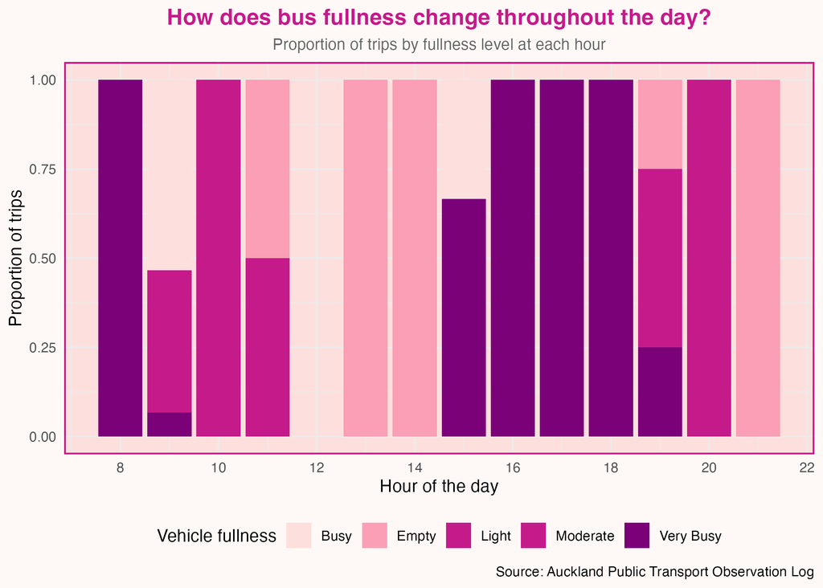

The early morning (8-9am) and late afternoon (5-6pm) are packed. The bus is standing room only, and I’m often squished between strangers. No wonder I was so uncomfortable. I reasonably suspect this is because people are travelling to work and school in the morning, then heading home again in the evening.

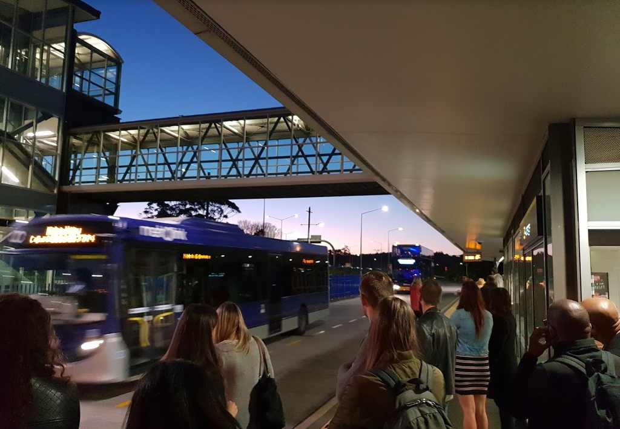

A fullness bus stop

## Who Rides the Bus at Different Times?

I also wanted to know who I was sharing the bus with. Was it mostly students like me? Or commuters heading to the office? Families with young children? Elderly passengers? So I logged the passenger groups I observed on each trip.

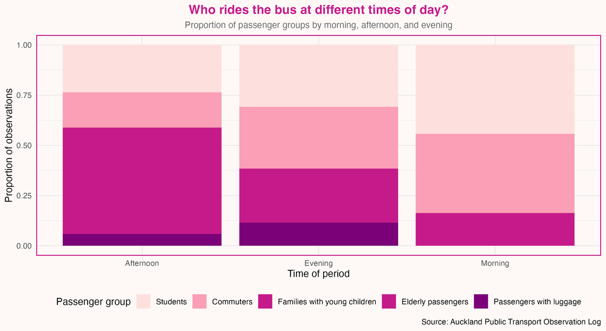

time of period vs. passanger groups

In the morning, the bus is full of students heading to university, along with commuters going to work. We all seem to be on the same schedule, rushing to get somewhere before 9am. In the evening, the same thing happens in reverse. Students are heading home after class, and commuters are leaving work. It feels like a familiar crowd.

[figure not shown]